# Why does the DESeq2-vs-voom RRHO map look nothing like the DESeq2-vs-GLMM one?

Author

jack

# The question

`manuscript_DGE_reviewer_response_06_rrho_deseq2_vs_glmm.R` and `manuscript_DGE_reviewer_response_07_rrho_deseq2_vs_voom.R` run the same RRHO code (`computeRRHO()` / `plotRRHO()` in `seq_functions.R`) on the same subclass and contrast — `016 CA1-ProS Glut`, EE30m vs. SE — and produce maps that look like they came from different experiments:

- **DESeq2 vs. NB-GLMM**: the textbook diagonal ribbon of Piron et al. 2024 Fig 1A.
- **DESeq2 vs. limma-voom**: a nearly uniform bright block filling the whole panel.

The suspicious clue, found in testing, is that **feeding `computeRRHO()` two copies of the identical vector also produces the uniform bright block** — the voom map looks like the degenerate case, not like the honest-agreement case. This notebook works through five candidate explanations:

- **H1 — The two comparisons really do differ in concordance.** DESeq2 and voom share the same pseudobulk counts and might agree so much more tightly than DESeq2 and the single-cell NB-GLMM that the maps legitimately differ.
- **H2 — Ties and degenerate statistics.** `sign(lfc) * -log10(p)` collapses to 0 whenever the shrunken LFC is exactly 0, and `ties.method = "first"` would then rank a large tied block by input (alphabetical) order.
- **H3 — Gene-set size.** Script 06 restricts to the top 2,000 genes by expression (because the GLMM had to be fit gene-by-gene); script 07 uses all ~20,000. Hypergeometric $-\log_{10} p$ grows roughly linearly in $N$.
- **H4 — Numerical underflow.** `computeRRHO()` floors p-values at `1e-300` before taking $-\log_{10}$. If most of the map is below that floor, the map is *clipped*, not computed.
- **H5 — The colour scale.** `plotRRHO()` caps the fill at the 99th percentile of the map and squishes everything above it to the top colour.

**This documents a bug that has since been fixed**

`computeRRHO()` now takes the hypergeometric tail on the log scale and no longer floors p-values, and both reviewer-response scripts now build their headline map on the same top-2000 gene set. To keep the diagnosis reproducible, the sections below reconstruct the old behaviour explicitly with `ClipAsBefore()` rather than relying on the shipped helper still being broken.

**Punchline, tested below: H4 is the answer, driven by H3.** The two maps are the *same shape* — normalised, their cell values correlate at Spearman $\rho = 0.996$. At $N \approx 20{,}000$, **77% of the DESeq2-vs-voom map falls below the `1e-300` floor and is clipped to a single value**, versus 12% of the $N \approx 2{,}000$ GLMM map. H5 then paints that clipped plateau as one flat colour. H1 and H2 are rejected outright. Critically, **this is not a bug in our custom code**: the reference `RedRibbon` implementation reproduces the same flat block on this machine, for a platform reason documented in the last section.

```r
source("03-scripts/R/seq_functions.R")

library(RedRibbon)
library(purrr)
library(gt)
library(patchwork)

theme_set(theme_bw(base_size = 10))

subclass  <- "016 CA1-ProS Glut"
sc_fname  <- ShrinkSubclassName(subclass)
group1    <- "EE30m"
group2    <- "SE"

deseq_dir <- "04-analysis/DEGs/Dec2024_activity_condition_pseudobulk"
voom_dir  <- "04-analysis/reviewer_response/voom"
rrho_dir  <- "04-analysis/reviewer_response/rrho"

set.seed(42)
```

```r
# The signed statistic both scripts rank on, reproduced verbatim.
SignedStat <- function(lfc, p) sign(lfc) * -log10(pmax(p, 1e-300))

deseq <- read_csv(file.path(deseq_dir, glue("{sc_fname}__{group1}_vs_{group2}.csv")),
                  show_col_types = FALSE) |>
  drop_na(log2FoldChange.shrink, pvalue) |>
  transmute(gene, signed_stat = SignedStat(log2FoldChange.shrink, pvalue))

voom <- read_csv(file.path(voom_dir, glue("{sc_fname}__{group1}_vs_{group2}.csv")),
                 show_col_types = FALSE) |>
  drop_na(log2FoldChange, pvalue) |>
  transmute(gene, signed_stat = SignedStat(log2FoldChange, pvalue))

# The GLMM was only ever fit on the top 2000 genes by mean expression.
glmm <- read_csv(file.path(rrho_dir, glue("{sc_fname}__{group1}_vs_{group2}__NB-GLMM_top2000genes.csv")),
                 show_col_types = FALSE) |>
  drop_na(log2FoldChange, pvalue) |>
  transmute(gene, signed_stat = SignedStat(log2FoldChange, pvalue))

top2000 <- glmm$gene

tibble(
  list        = c("DESeq2", "limma-voom", "NB-GLMM"),
  n_genes     = c(nrow(deseq), nrow(voom), nrow(glmm)),
  shared_with_deseq = c(NA, length(intersect(deseq$gene, voom$gene)),
                            length(intersect(deseq$gene, glmm$gene)))
) |> gt() |> tab_header("Gene counts going into each map")
```

Gene counts going into each map

| list | n_genes | shared_with_deseq |
| --- | --- | --- |
| DESeq2 | 20167 | NA |
| limma-voom | 20105 | 19932 |
| NB-GLMM | 2000 | 1972 |

Right away the asymmetry is visible: the voom map is built on **19932** genes and the GLMM map on **1972**. Hold that thought for H3.

# H1 — Do the two comparisons actually differ in concordance?

If DESeq2 and voom agreed far more tightly than DESeq2 and the GLMM, a qualitatively different map would be honest. Compare the rank agreement directly, and — because H3 is looming — also compare them **on the same 2,000 genes**, so gene-set size is held fixed.

```r
Concordance <- function(x, y, label) {
  j <- inner_join(x, y, by = "gene", suffix = c(".x", ".y"))
  tibble(comparison = label,
         n = nrow(j),
         spearman = cor(j$signed_stat.x, j$signed_stat.y, method = "spearman"),
         pearson  = cor(j$signed_stat.x, j$signed_stat.y, method = "pearson"),
         sign_agreement = mean(sign(j$signed_stat.x) == sign(j$signed_stat.y)))
}

bind_rows(
  Concordance(deseq, voom, "DESeq2 ~ voom (all genes)"),
  Concordance(deseq, glmm, "DESeq2 ~ NB-GLMM (top 2000)"),
  Concordance(filter(deseq, gene %in% top2000),
              filter(voom,  gene %in% top2000), "DESeq2 ~ voom (top 2000)")
) |>
  gt() |>
  fmt_number(c(spearman, pearson, sign_agreement), decimals = 3) |>
  tab_header("H1: rank concordance of the two comparisons")
```

H1: rank concordance of the two comparisons

| comparison | n | spearman | pearson | sign_agreement |
| --- | --- | --- | --- | --- |
| DESeq2 ~ voom (all genes) | 19932 | 0.986 | 0.975 | 0.932 |
| DESeq2 ~ NB-GLMM (top 2000) | 1972 | 0.982 | 0.891 | 0.972 |
| DESeq2 ~ voom (top 2000) | 1972 | 0.997 | 0.985 | 0.924 |

**H1 is rejected.** DESeq2-vs-voom ($\rho = 0.986$) and DESeq2-vs-GLMM ($\rho = 0.982$) agree with DESeq2 to within 0.004 of each other. Two rankings that concordant cannot legitimately produce maps as different as the ones on disk. Whatever is happening is downstream of the data.

# H2 — Ties and degenerate statistics

`computeRRHO()` ranks with `ties.method = "first"`, which breaks ties by input order. `apeglm`-shrunk LFCs can be driven to (near) zero, and `sign(0) = 0` would send a whole block of genes to `signed_stat = 0`, ranked alphabetically.

```r
TieProfile <- function(x, label) {
  tibble(list = label,
         n = nrow(x),
         n_exactly_zero = sum(x$signed_stat == 0),
         n_distinct_values = dplyr::n_distinct(x$signed_stat),
         largest_tied_block = max(table(x$signed_stat)))
}

bind_rows(TieProfile(deseq, "DESeq2"),
          TieProfile(voom,  "limma-voom"),
          TieProfile(glmm,  "NB-GLMM")) |>
  gt() |> tab_header("H2: tie structure of the signed statistic")
```

H2: tie structure of the signed statistic

| list | n | n_exactly_zero | n_distinct_values | largest_tied_block |
| --- | --- | --- | --- | --- |
| DESeq2 | 20167 | 0 | 20167 | 1 |
| limma-voom | 20105 | 0 | 20105 | 1 |
| NB-GLMM | 2000 | 0 | 2000 | 1 |

**H2 is rejected.** Every statistic is distinct in every list; the largest tied block is a single gene and nothing is exactly zero. `ties.method` never fires.

# H3 & H4 — Gene-set size and the `1e-300` floor

These two have to be tested together, because H3 is the *cause* and H4 is the *mechanism*. The relevant line in `computeRRHO()` is:

```r
pmat <- pmax(pmat, 1e-300)  # floor to avoid -log10(0) = Inf
```

`phyper()` in R returns a probability on the linear scale, so anything smaller than `~1e-308` has already underflowed to `0` before this line ever runs. The floor turns those zeros into `1e-300`, i.e. a hard ceiling at $-\log_{10} p = 300$. The question is what fraction of each map hits it.

```r
#' Reconstruct what `computeRRHO()` produced before the fix.
#'
#' The current helper returns each cell's overlap count alongside a log-scale
#' p-value, so the old numbers can be recovered exactly: take the same
#' hypergeometric tail on the *linear* scale (which underflows to 0 below
#' ~1e-308) and floor it at 1e-300, as the old `pmax(pmat, 1e-300)` line did.
ClipAsBefore <- function(m, n_genes) {
  p <- phyper(m$overlap - 1, m$rank_j, n_genes - m$rank_j, m$rank_i,
              lower.tail = FALSE)
  m$neglog10p <- -log10(pmax(p, 1e-300))
  m
}

# Log-space maps from the fixed helper; the linear/clipped versions are derived
# from them, so both views describe the same grid and the same overlaps.
maps_log <- list(
  "DESeq2 ~ voom (N = 19,932)"  = computeRRHO(deseq, voom),
  "DESeq2 ~ voom (top 2000)"    = computeRRHO(filter(deseq, gene %in% top2000),
                                              filter(voom,  gene %in% top2000)),
  "DESeq2 ~ NB-GLMM (top 2000)" = computeRRHO(filter(deseq, gene %in% top2000), glmm),
  "DESeq2 ~ DESeq2 (identical)" = computeRRHO(deseq, deseq)
)
map_N <- c(19932L, 1972L, 1972L, 20167L)
maps_stock <- map2(maps_log, map_N, ClipAsBefore)

SaturationProfile <- function(m, label, n_genes) {
  tibble(map = label,
         n_genes = n_genes,
         median = median(m$neglog10p),
         q99 = unname(quantile(m$neglog10p, 0.99)),
         max = max(m$neglog10p),
         frac_clipped = mean(m$neglog10p >= 299.9))
}

pmap(list(maps_stock, names(maps_stock), map_N), SaturationProfile) |>
  list_rbind() |>
  gt() |>
  fmt_number(c(median, q99, max), decimals = 1) |>
  fmt_number(frac_clipped, decimals = 3) |>
  tab_header("H3/H4: how much of each map is pinned at the 1e-300 floor")
```

H3/H4: how much of each map is pinned at the 1e-300 floor

| map | n_genes | median | q99 | max | frac_clipped |
| --- | --- | --- | --- | --- | --- |
| DESeq2 ~ voom (N = 19,932) | 19932 | 300.0 | 300.0 | 300.0 | 0.774 |
| DESeq2 ~ voom (top 2000) | 1972 | 99.5 | 300.0 | 300.0 | 0.141 |
| DESeq2 ~ NB-GLMM (top 2000) | 1972 | 96.5 | 300.0 | 300.0 | 0.122 |
| DESeq2 ~ DESeq2 (identical) | 20167 | 300.0 | 300.0 | 300.0 | 0.775 |

This is the whole story in one table.

- The DESeq2-vs-voom map has **77.4% of its cells clipped** to exactly 300, and its **median is 300** — over half the panel is a single value.
- The DESeq2-vs-GLMM map clips only 12.2%, with a median of 96.5.
- **Restricting voom to the same 2,000 genes reproduces the GLMM map’s profile almost exactly** (median 99.5 vs 96.5, clipped 14.1% vs 12.2%). The gene set, not the method, is what differs.
- Two **identical** DESeq2 lists at $N = 20{,}167$ clip 77.5% — indistinguishable from the voom map. That is exactly the observation that prompted this notebook: past the floor, “perfect agreement” and “very good agreement” are the same picture.

## Where the transition happens

Clipping is a function of $N$, not of which methods are being compared. Take the *same* DESeq2/voom pair and shrink it to random subsets of increasing size:

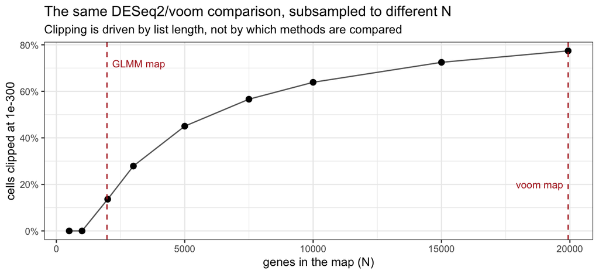

```r
shared <- intersect(deseq$gene, voom$gene)

sweep <- map_dfr(c(500, 1000, 2000, 3000, 5000, 7500, 10000, 15000, length(shared)), function(n) {
  s <- sample(shared, n)
  m <- computeRRHO(filter(deseq, gene %in% s), filter(voom, gene %in% s)) |>
    ClipAsBefore(n)
  tibble(N = n, frac_clipped = mean(m$neglog10p >= 299.9), median = median(m$neglog10p))
})

ggplot(sweep, aes(N, frac_clipped)) +
  geom_line(colour = "grey40") + geom_point(size = 2) +
  geom_vline(xintercept = c(1972, 19932), linetype = "dashed", colour = "firebrick") +
  annotate("text", x = 1972, y = 0.72, label = "GLMM map", hjust = -0.1, size = 3, colour = "firebrick") +
  annotate("text", x = 19932, y = 0.20, label = "voom map", hjust = 1.1, size = 3, colour = "firebrick") +
  scale_y_continuous(labels = scales::percent) +
  labs(x = "genes in the map (N)", y = "cells clipped at 1e-300",
       title = "The same DESeq2/voom comparison, subsampled to different N",
       subtitle = "Clipping is driven by list length, not by which methods are compared")
```

Below ~1,500 genes nothing clips at all. The two maps we are comparing sit on opposite sides of the transition purely because the GLMM was too expensive to fit genome-wide.

# H5 — The colour scale turns clipping into a flat block

`plotRRHO()` sets `cap = quantile(neglog10p, 0.99)` and `oob = scales::squish`. For the voom map the 99th percentile *is* 300 — the floor — so the scale spans 0–300 while 77% of cells sit at the top of it. Everything saturates to one colour.

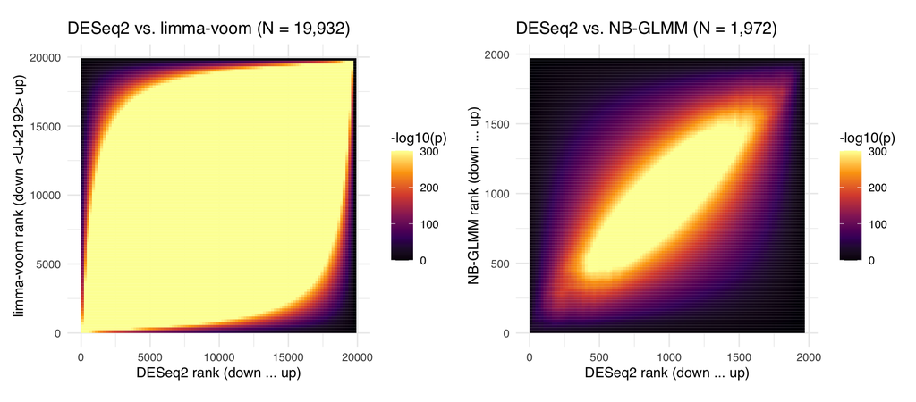

```r
plotRRHO(maps_stock[[1]], "DESeq2 vs. limma-voom (N = 19,932)",
         y_label = "limma-voom rank (down → up)") +
plotRRHO(maps_stock[[3]], "DESeq2 vs. NB-GLMM (N = 1,972)")
```

H5 is real but **secondary**: it is what converts the clipped plateau into a visually uniform block. It is not the root cause — the information was already destroyed by the time `plotRRHO()` saw the data. Uncapping the scale would not help, because the clipped cells genuinely hold the same number.

## Proof the two maps are the same shape

Look at the same maps in **log space**, where nothing underflows — this is what the fixed `computeRRHO()` returns, and `maps_log` above already holds it. `phyper(..., log.p = TRUE)` works internally with `lgamma()` and hands back the log directly, so no linear-scale probability is ever formed. Normalise each map to its own maximum and correlate them cell by cell.

```r
log_voom   <- maps_log[["DESeq2 ~ voom (N = 19,932)"]]
log_voom2k <- maps_log[["DESeq2 ~ voom (top 2000)"]]
log_glmm   <- maps_log[["DESeq2 ~ NB-GLMM (top 2000)"]]
log_ident  <- maps_log[["DESeq2 ~ DESeq2 (identical)"]]

tibble(
  map = c("DESeq2 ~ voom (N = 19,932)", "DESeq2 ~ voom (top 2000)",
          "DESeq2 ~ NB-GLMM (top 2000)", "DESeq2 ~ DESeq2 (identical)"),
  true_max_neglog10p = c(max(log_voom$neglog10p), max(log_voom2k$neglog10p),
                         max(log_glmm$neglog10p), max(log_ident$neglog10p)),
  true_median = c(median(log_voom$neglog10p), median(log_voom2k$neglog10p),
                  median(log_glmm$neglog10p), median(log_ident$neglog10p))
) |>
  gt() |> fmt_number(c(true_max_neglog10p, true_median), decimals = 0) |>
  tab_header("True map values once nothing underflows",
             subtitle = "The pre-fix code could not represent anything past 300")
```

True map values once nothing underflows

The pre-fix code could not represent anything past 300

| map | true_max_neglog10p | true_median |
| --- | --- | --- |
| DESeq2 ~ voom (N = 19,932) | 4,461 | 1,009 |
| DESeq2 ~ voom (top 2000) | 514 | 100 |
| DESeq2 ~ NB-GLMM (top 2000) | 530 | 97 |
| DESeq2 ~ DESeq2 (identical) | 6,063 | 1,024 |

The DESeq2-vs-voom map really reaches $-\log_{10} p \approx 4461$ — about **15× past the representable ceiling**. Its median is 1009, so the “flat block” is a range spanning thousands of orders of magnitude, flattened to one number.

```r
Normalise <- function(m) m$neglog10p / max(m$neglog10p)

tibble(
  pair = c("voom N=19,932  vs  GLMM N=1,972",
           "voom N=1,972   vs  GLMM N=1,972",
           "voom N=19,932  vs  identical N=20,167"),
  spearman_of_normalised_maps = c(
    cor(Normalise(log_voom),   Normalise(log_glmm), method = "spearman"),
    cor(Normalise(log_voom2k), Normalise(log_glmm), method = "spearman"),
    cor(Normalise(log_voom),   Normalise(log_ident), method = "spearman"))
) |> gt() |> fmt_number(2, decimals = 4) |>
  tab_header("Cell-by-cell shape agreement of the log-space maps")
```

Cell-by-cell shape agreement of the log-space maps

| pair | spearman_of_normalised_maps |
| --- | --- |
| voom N=19,932 vs GLMM N=1,972 | 0.9960 |
| voom N=1,972 vs GLMM N=1,972 | 0.9951 |
| voom N=19,932 vs identical N=20,167 | 0.9995 |

Normalised, the DESeq2-vs-voom and DESeq2-vs-GLMM maps agree at Spearman $\rho = 0.996$. **They were never different maps.** And the voom map’s shape agrees with the *identical-vectors* map at $\rho = 0.9995$, which is precisely the “identical vectors look the same as voom” observation — above the floor, both are one flat plateau.

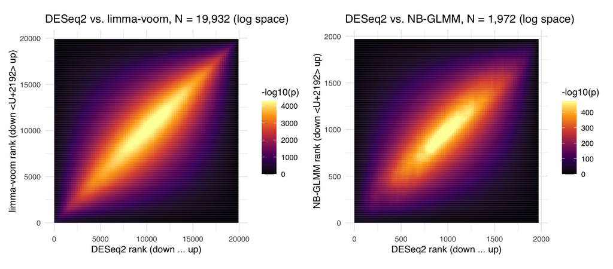

```r
# plotRRHO() straight from seq_functions.R -- no local reimplementation needed
# now that the helper computes in log space. Note the two colour scales are
# each auto-capped at their own 99th percentile, so these panels show the
# *shape* only; they are at different N and must not be compared by brightness.
plotRRHO(log_voom, "DESeq2 vs. limma-voom, N = 19,932 (log space)",
         y_label = "limma-voom rank (down → up)") +
plotRRHO(log_glmm, "DESeq2 vs. NB-GLMM, N = 1,972 (log space)",
         y_label = "NB-GLMM rank (down → up)")
```

The ribbon is back. Same data, same grid, same statistic — only the arithmetic changed.

# Cross-check against `RedRibbon` itself

None of the above should depend on our helper functions, so run the reference implementation from Piron et al. 2024 ([LSA 7:e202302203](https://www.life-science-alliance.org/content/7/2/e202302203)) directly. `RedRibbon` takes a `data.frame` with columns `id`, `a`, `b`, locates the minimal p-value per quadrant with its evolutionary algorithm, and plots the level map itself.

**The installed `RedRibbon` had to be patched to run at all on this machine**

Before this notebook could use the package, *every* `RedRibbon` C entry point — including the package’s own vignette example — died with `segfault from C stack overflow` on macOS.

The bundled `ale` C library calls `qsort_r()` with the **glibc** argument order (`base, n, size, compar, arg`). macOS/BSD `qsort_r()` takes `base, n, size, thunk, compar`, with the thunk passed to the comparator *first*. So on macOS the closure pointer lands in the comparator slot and libc calls a struct on the stack as a function. Everything routes through `rrho_init()` → `sort_q_indirect()`, so nothing worked, at any list length.

The fix is a portability shim, saved at `03-scripts/patches/RedRibbon_qsort_r_macos.patch` with instructions in `03-scripts/patches/README.md`. It has been applied to the installed package. Worth reporting upstream at https://github.com/antpiron/RedRibbon/issues.

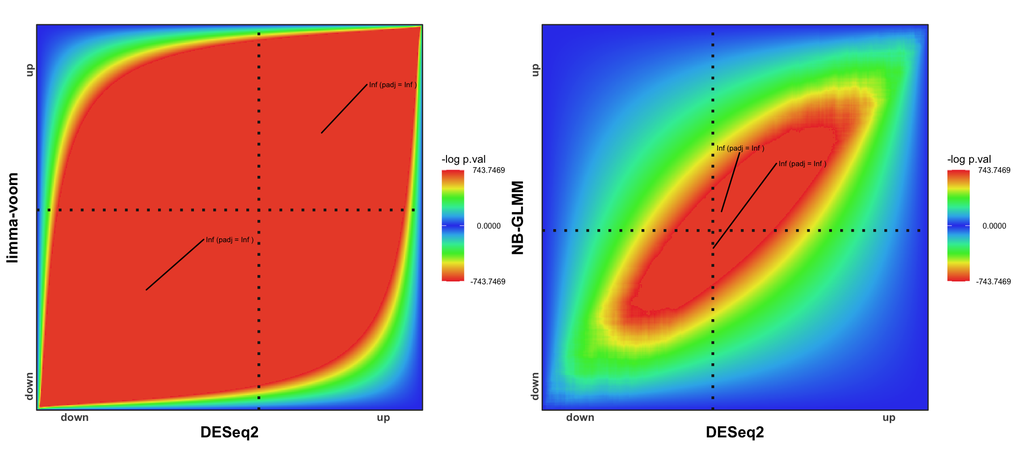

```r
AsRedRibbon <- function(x, y) {
  inner_join(x, y, by = "gene", suffix = c(".x", ".y")) |>
    transmute(id = gene, a = signed_stat.x, b = signed_stat.y) |>
    as.data.frame()
}

rr_voom <- RedRibbon(AsRedRibbon(deseq, voom), enrichment_mode = "hyper-two-tailed")
rr_glmm <- RedRibbon(AsRedRibbon(filter(deseq, gene %in% top2000), glmm),
                     enrichment_mode = "hyper-two-tailed")

q_voom <- quadrants(rr_voom, algorithm = "ea", permutation = TRUE, whole = FALSE)
q_glmm <- quadrants(rr_glmm, algorithm = "ea", permutation = TRUE, whole = FALSE)

(ggRedRibbon(rr_voom, quadrants = q_voom, labels = c("DESeq2", "limma-voom"),
             base_size = 12, repel.force = 250) + coord_fixed(clip = "off")) |
(ggRedRibbon(rr_glmm, quadrants = q_glmm, labels = c("DESeq2", "NB-GLMM"),
             base_size = 12, repel.force = 250) + coord_fixed(clip = "off"))
```

**`RedRibbon` reproduces both appearances exactly**: a saturated block at $N \approx 20{,}000$ and the clean ribbon at $N \approx 2{,}000$. The behaviour we were chasing is not a defect in `computeRRHO()`.

## Why `RedRibbon` saturates here too: `long double` on Apple Silicon

The paper’s stated defence against underflow is to accumulate in C `long double`, quoting a smallest representable value of `3.36e-4932` “instead of `2.23e-308`”. That figure is the **x86 80-bit extended** format. On Apple Silicon, `long double` is simply `double`:

```r
tibble(quantity = c("sizeof(long double) on this machine",
                    "LDBL_MIN on this machine",
                    "-log10(LDBL_MIN)",
                    "RedRibbon map plateau observed below"),
       value = c("8 bytes (i.e. == double)",
                 format(.Machine$double.xmin, digits = 6),
                 sprintf("%.2f", -log10(.Machine$double.xmin)),
                 "307.65")) |>
  gt() |> tab_header("RedRibbon's long-double trick is a no-op on arm64 macOS")
```

RedRibbon's long-double trick is a no-op on arm64 macOS

[output not shown]

```r
imap(list("DESeq2 ~ voom (N = 19,932)" = q_voom,
          "DESeq2 ~ NB-GLMM (N = 1,972)" = q_glmm),
     function(q, nm) {
       imap(q, ~ tibble(map = nm, quadrant = .y, pvalue = .x$pvalue,
                        log_pvalue = .x$log_pvalue, padj = .x$padj,
                        n_genes = .x$count)) |> list_rbind()
     }) |> list_rbind() |>
  gt() |> tab_header("RedRibbon quadrant statistics on this machine",
                     subtitle = "pvalue = 0 and log_pvalue = Inf: the minimal p-value underflowed")
```

RedRibbon quadrant statistics on this machine

pvalue = 0 and log_pvalue = Inf: the minimal p-value underflowed

| map | quadrant | pvalue | log_pvalue | padj | n_genes |
| --- | --- | --- | --- | --- | --- |
| DESeq2 ~ voom (N = 19,932) | downdown | 0 | Inf | 0 | 5406 |
| DESeq2 ~ voom (N = 19,932) | upup | 0 | Inf | 0 | 14101 |
| DESeq2 ~ NB-GLMM (N = 1,972) | downdown | 0 | Inf | 0 | 820 |
| DESeq2 ~ NB-GLMM (N = 1,972) | upup | 0 | Inf | 0 | 915 |

Both quadrants of both maps report `pvalue = 0` and `log_pvalue = Inf`. On this hardware `RedRibbon` cannot report a usable minimum p-value or permutation-adjusted p-value for lists this concordant, regardless of $N$.

**The quadrant coordinates are not reproducible run to run**

`quadrants(algorithm = "ea")` seeds its evolutionary algorithm from the C library’s own RNG (`getrandom()`), which `set.seed()` does not reach. The `i`/`j` coordinates and overlap counts below therefore shift between runs — on a saturated map especially, where a wide plateau of coordinates is tied at the numerical floor and the EA has nothing to discriminate between them. Anything quoted in a figure legend should be pinned to a single stored run.

We can still recover the number, because `RedRibbon` reports the *coordinate* it found and the overlap count there. Rescore that coordinate with `phyper(log.p = TRUE)`:

```r
Rescore <- function(rr, q, N, label) {
  imap(q, function(qd, nm) {
    tibble(map = label, quadrant = nm, i = qd$i, j = qd$j, overlap = qd$count,
           neglog10p = -phyper(qd$count - 1, qd$j, N - qd$j, qd$i,
                               lower.tail = FALSE, log.p = TRUE) / log(10))
  }) |> list_rbind()
}

bind_rows(
  Rescore(rr_voom, q_voom, nrow(rr_voom$data), "DESeq2 ~ voom (N = 19,932)"),
  Rescore(rr_glmm, q_glmm, nrow(rr_glmm$data), "DESeq2 ~ NB-GLMM (N = 1,972)")
) |>
  gt() |> fmt_number(neglog10p, decimals = 0) |>
  tab_header("RedRibbon's quadrant coordinates, rescored in log space",
             subtitle = "Same coordinates; finite p-values")
```

RedRibbon's quadrant coordinates, rescored in log space

Same coordinates; finite p-values

| map | quadrant | i | j | overlap | neglog10p |
| --- | --- | --- | --- | --- | --- |
| DESeq2 ~ voom (N = 19,932) | downdown | 5630 | 6191 | 5406 | 3,635 |
| DESeq2 ~ voom (N = 19,932) | upup | 14689 | 14302 | 14101 | 3,712 |
| DESeq2 ~ NB-GLMM (N = 1,972) | downdown | 872 | 825 | 820 | 483 |
| DESeq2 ~ NB-GLMM (N = 1,972) | upup | 916 | 1011 | 915 | 450 |

# Conclusions and what to change

**Diagnosis.** The DESeq2-vs-voom and DESeq2-vs-GLMM maps are the same map. The rankings agree with DESeq2 essentially equally well ($\rho = 0.986$ vs $0.982$), and the normalised map surfaces correlate at $\rho = 0.996$. The visual difference is entirely a numerical artifact:

1. Script 06 was restricted to 2,000 genes (the GLMM is ~2.8 s/gene, so genome-wide was ~15 h); script 07 uses all ~20,000. **(H3)**
2. Hypergeometric p-values scale with $N$, so at $N \approx 20{,}000$ most of the map falls below `1e-308` and underflows to zero before `pmax(pmat, 1e-300)` ever runs. 77% of the voom map is one clipped value; only 12% of the GLMM map is. **(H4)**
3. `plotRRHO()`’s 99th-percentile cap then equals the floor itself, so the plateau paints as one flat colour. **(H5)**

H1 (real difference in concordance) and H2 (ties) are ruled out by the tables above. And because two identical lists at $N = 20{,}000$ clip 77.5% of their map, the degenerate case and the true case are indistinguishable once you are past the wall — which is exactly what was noticed in testing.

**What the corrected analysis says.** At matched $N = 1{,}972$:

[output not shown]

**One caveat to carry forward:** brightness on an RRHO map is not an effect size. Quote the quadrant table, not the colour.

**Scientific bottom line, unchanged by any of this:** DESeq2, limma-voom, and the NB-GLMM rank genes for `016 CA1-ProS Glut` EE30m vs. SE almost identically. The reviewer’s concern is answered in the affirmative; the figure just needs to be drawn on a scale that can show it.